# Class 10: Aspects of Social Movement Activity

Counter-mobilisation and countermovements

[Dr. Michael C. Zeller](https://michaelzeller.de)

# Opening notes

[Open Sticker](https://tenor.com/view/open-gif-14209777)from [Open Stickers](https://tenor.com/search/open-stickers)

## Presentation groups

Presentations line-up

| Date | Presenters | Method |
| --- | --- | --- |
| 4 Dec: | Daichi, Seongyeon, Jehyun | ethnography |
| 18 Dec: | Ayla, Tara, Theresa, Annabelle | TBD |
| 15 Jan: | Luna, Emilene, Raffa, Sofia | TBD |

# Counter-mobilisation

- opening questions
- The Sticker War
- counter-mobilisation causes and effects

[Mirror, Mirror GIF](https://tenor.com/view/same-mirror-reflection-copying-mimicking-gif-4361714)from [Same GIFs](https://tenor.com/search/same-gifs)

## Opening questions

What is counter-mobilisation? What is a countermovement?

## The Sticker War

[figure not shown]

[figure not shown]

A Serbian antifa named Stefan waged a similar campaign on his own in 2012: When he came upon wheat-pasted posters from the fascist Serbian Action in his neighborhood of Belgrade, he immediately tore them down … and noticed them back up again an hour later. He retaliated by plastering antifa stickers all over the Serbian Action posters … only to find Serbian Action stickers in favor of “Traditional courtship in marriage” and other conservative slogans plastered on top of his stickers in response. Every day for six months Stefan battled with an anonymous fascist for control of his neighborhood. About four months into the conflict Stefan saw a guy putting up a sticker down the street as he got off the bus. The two locked eyes but Stefan wasn’t sure if this was his nemesis. In any event, Stefan persisted, and eventually the Serbian Action propaganda ceased to appear. He simply outlasted them.

*p121*: The street art campaigns, whether posters or graffiti, ultimately serve to designate space as antifascist (Creasap 2016; Gerbaudo 2013; Waldner and Dobratz 2013). An antifascist tag or sticker in a dive bar signifies the space as welcoming to activists and hostile to fascists. Antifa posters or stickers on lamp posts or walls in a community show that at minimum there is an active militant antifascist group operating in the area.

Vysotsky, S. (2020). *American Antifa: The tactics, culture, and practice of militant antifascism*. Routledge.

## Opening questions

What is counter-mobilisation? What is a countermovement?

Is ‘countering’ inherently disadvantaged/weaker by being reactive?

What counter-mobilisation/countermovement (if any) exists in cases you know of?

## counter-mobilisation causes and effects (Reynolds-Stenson and Earl 2018)

- using data from U.S. (*NYT*) between **1960** and **1995** and **logistic regression** techniques
  - counterdemonstration is rare: only at *7 per cent* of protests
  - counterdemonstration more likely at big events (>10,000 participants)
    - **awareness**/**attention** mechanism probably at work
  - demos by movements that have recently held several protests are *more likely* to provoke counterdemonstration
  - more media coverage and more SMOs involved in demo makes it *more likely* to provoke counterdemonstration
    - **awareness**/**attention** mechanism probably at work
  - when movements appear strong, counterprotests is *more likely*
    - **threat** mechanisms at work
- Recent study in Austria (Weisskircher 2023) counter-mobilisation at PEGIDA led to higher attendance; and at the ‘Akademikerball’ led to greater sense of **collective identity** (but less participation) (complex causation)

## Less visible countering examples

**From the far right – anti-far right *opposing movements* pair**

- Leeds United fans make fan magazine (*Marching Altogether*) to supplant far-right magazine (*Bulldog*) (Conlon 2017)
- regular antifa disruption causes Richard Spencer (US alt-right activist) to call speaking tour (Lennard 2018)
- SumOfUs pressured Paypal to forbid Bündnis Pro Chemnitz from receiving funds via its service (Kienzl 2019)
- Graffiti removal/alteration in Cottbus (Jetzt.de 2019)
- *Zentrum für politische Schönheit* (ZPS)
  - makes honey trap tool for far-right demonstrators to search if they were at Chemnitz; doxxing exercise (von Jutrczenka 2018)
  - got contract to distribute flyers for AfD; returned them to party two days before 2021 election (Nasr 2021)

# Poll: counter-mobilisation

[figure not shown]

Take the survey at **https://forms.gle/RD2Cb4fEFdufsa8v6**

- which type of actor provides the strongest opposition to this movement?
- does the movement face sustained organised opposition from another movement(s)?
- has counter-mobilisation changed the movement’s tactics?
- has counter-mobilisation increased political polarisation around the movement’s main issue?
- has counter-mobilisation more strengthened or weakened the movement?

[interactive chart not shown]

type of actor providing strongest opposition?

[interactive chart not shown]

sustained opposition from another movement(s)?

[interactive chart not shown]

## Movement responses - tactics effect

counter-mobilisation changed the movement’s tactics?

[interactive chart not shown]

## Movement responses - issue effect

counter-mobilisation increased polarisation around the movement’s main issue?

[interactive chart not shown]

## Movement responses - overall effect

counter-mobilisation more strengthened or weakened the movement?

[interactive chart not shown]

# Countermovements

- countermovement/opposing movement characteristics
- countermovement emergence
  - critical events; threats
  - example: Just Stop Oil
- countermovement campaign: *Laut gegen Nazis*
- triadic contention
- inherent disadvantage?

[I Cast Counter Counterspell Wizard GIF](https://tenor.com/view/i-cast-counter-counterspell-counter-counterspell-counterspell-i-cast-wizard-gif-7921438966093719474)from [I Cast Counter Counterspell GIFs](https://tenor.com/search/i+cast+counter+counterspell-gifs)

## Countermovement

**countermovement** (intuitively…) is ‘a movement that makes contrary claims simultaneously to those of the original movement’ (1996, 1631), involving **sustained counter-mobilisation**

- countermovements are…
  - dynamically engaged with and related to an oppositional movement (Lo 1982; cf. Mayer 1995)
  - *not* inherently reactionary (i.e., opposed to social change) (contrary to Mottl 1980) — they are ‘reactive’ but can be progressive or conservative or regressive
    - came from a misleading focus on ‘conservative oppositional movements’ (Lo 1982)
  - (at least initially) propelled by the example of an originating movement (e.g., strategies/tactics, symbols, exploited opportunities)
  - like other movements, in dynamic interaction with the state $\rightarrow$ triadic interaction (Zald and Useem 1987)

## Countermovement/Opposing movement characteristics

polarisation

dependency

Manicheism

imitation

## Countermovement/Opposing movement characteristics

dependency

Manicheism

imitation

polarisation

- most CM activities will be directed against the target movement and vice versa, aimed at “neutralizing, confronting or discrediting its corresponding countermovement” (Zald and Useem 1987, 148)
- e.g., anti-immigration vs. migrant rights movements: rhetoric from both focused on the ‘threats’ posed by the other side

## Countermovement/Opposing movement characteristics

polarisation

dependency

Manicheism

imitation

## Countermovement/Opposing movement characteristics

polarisation

Manicheism

imitation

dependency

- mobilisation, and success on one side needing to be triggered by success and mobilisation on the other side, each movement thriving paradoxically on the good health of its opponent
- e.g., climate change denial/resistance vs. climate protection movements: demonstrations, policy influence by one has typically spurred on responsive activity

## Countermovement/Opposing movement characteristics

polarisation

dependency

Manicheism

imitation

## Countermovement/Opposing movement characteristics

polarisation

dependency

imitation

Manicheism

- us-them dynamic between opposed movements
- e.g., fundamentalist Christian vs. LGBTQ rights movements: the former frame LGBTQ rights movement and its supporters as complete ‘other’, a moral and cultural threat to “traditional family values”; LGBTQ rights movements in turn frame fundamentalists as opponents of basic human rights and dignity
  - ‘*In a racist society it is not enough to be non-racist, we must be anti-racist.*’ (Angela Davis)

## Countermovement/Opposing movement characteristics

polarisation

dependency

Manicheism

imitation

## Countermovement/Opposing movement characteristics

polarisation

dependency

Manicheism

imitation

- tendency to adopt elements of the other side’s programme, tactics, etc.
- e.g., ‘autonomist’ nationalists vs. left-wing/anarchist movements: C. Worch tries to import ‘black bloc’ tactic into German extreme right in 2000s; CasaPound Italia uses ‘squatting’ tactic in activism in Rome

## Countermovement/Opposing movement characteristics

polarisation

dependency

Manicheism

imitation

## Countermovement/Opposing movement characteristics

polarisation - *most CM activities will be directed against the target movement and vice versa, aimed at “neutralizing, confronting or discrediting its corresponding countermovement”* (Zald and Useem 1987, 148)

dependency - *mobilisation, and success on one side needing to be triggered by success and mobilisation on the other side, each movement thriving paradoxically on the good health of its opponent*

Manicheism - *us-them dynamic between opposed movements*

imitation - *tendency to adopt elements of the other side’s programme, tactics, etc.*

- Mayer (1995) examines these features in the case of Front National vs. SCALP, Ras l’Front, SOS, Le Manifeste contre le FN

## Countermovement emergence

Countermovements become more likely when…

1. an originating movement shows signs of success
2. that success includes threats to existing interests
3. (elite) allies are available to support counter-mobilisation

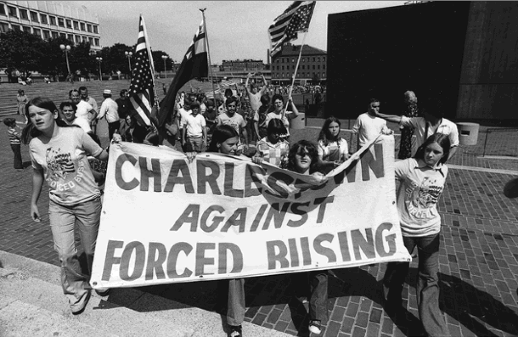

## Countermovement emergence

- An originating movement is successful when it…
  - gets issues on the public/political agenda
  - its narratives/frames are adopted in the media/public discourse
  - public policy changes
- Meyer and Staggenborg (1996) suggest movement success and countermovement emergence is **curvilinear**:
  - movements that achieve *some* success provoke countermovements
  - movements that achieve *no* or *little* success less likely to provoke countermovements
  - *complete* success also less likely to provoke counter- movements **because that success often closes opportunities** (the issue is ‘closed’)

## Countermovement emergence

- **divided governments/authorities** are more likely to provoke movement-countermovement contention because … **???**
- **federal systems** are more likely to sustain movement-countermovement contention because … **???**

## Countermovement emergence

- **divided governments/authorities** are more likely to provoke movement-countermovement contention because they cannot decisively ‘close’ issues
- **federal systems** are more likely to sustain movement-countermovement contention because there are many other **venues/arenas**

## Countermovement emergence - critical events

When movements create or exploit **critical events**, they also encourage countermovements

- critical events, for movements, can be government or state actions, accidents/incidents, large or conspicuous demonstrations
- what were the critical events for your movement?
- did they provoke counter-mobilisation or countermovement?

[figure not shown]

## Countermovement emergence - threats to interests

- countermovements are more likely to emerge when there is a *threat to interests*, especially of *large numbers of people and/or powerful persons or groups*
  - $\hookrightarrow$ that is, especially threats that run along cleavages
    - e.g., abortion rights in religious countries (*religious-secular cleavage*)

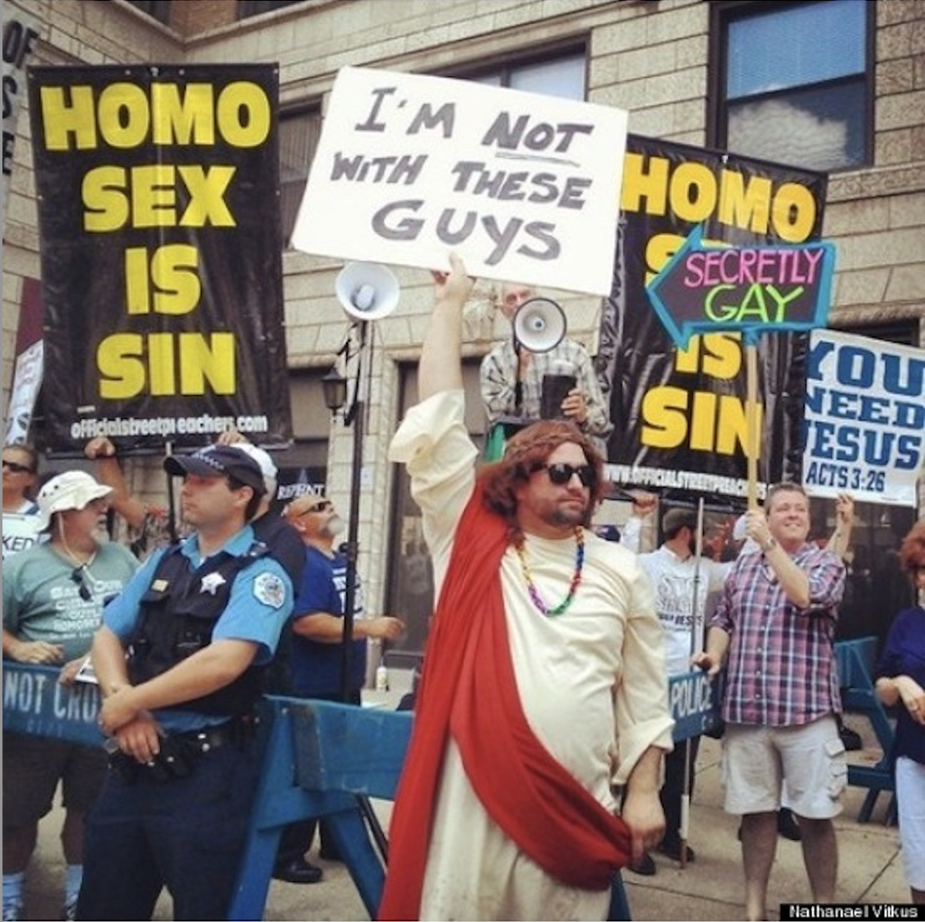

- **mass media** tends to seek out opposing interests to a movement’s claims (for ‘balanced coverage’) $\rightarrow$ encourages countermovements

## a countermovement emerging?

[figure not shown]

[figure not shown]

## a countermovement emerging?

JSO - JSPEO: counter-mobilisation in July 2023, south London:

[video not shown]

## a countermovement emerging?

JSO - JSPEO: counter-mobilisation in July 2023, south London:

- might presage countermovement (uniquely: mainly about tactics?)
- what do you notice about the activists and counter-activists in this video?

movement-countermovement conflict can continue over **very long periods** as sides trade-off victories and setbacks

[video not shown]

## an active countermovement campaign, [LGN](https://www.theguardian.com/world/2024/jan/08/german-anti-fascists-aim-trademark-nazi-slogans-hit-where-hurts)

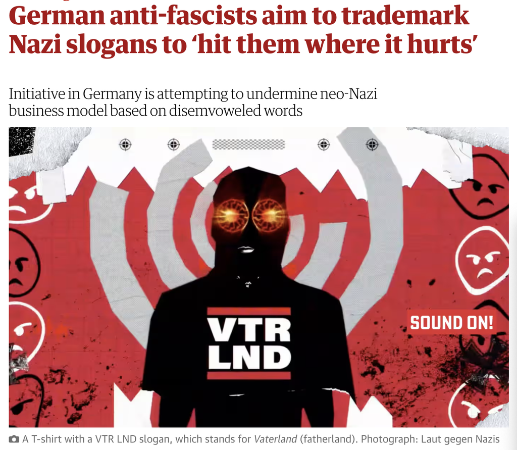

https://www.theguardian.com/world/2024/jan/08/german-anti-fascists-aim-trademark-nazi-slogans-hit-where-hurts

## Triadic contention

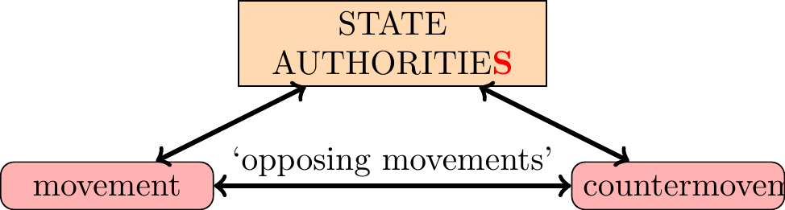

- movements and countermovements form part of the opportunity structure of each other
  - constrains the **strategy** and **tactics** available to movements and countermovements: demands (incl. *frames*), arenas (incl. *targets* and *levels of action*), tactics (*institutional*/*demonstrative* and/or *direct action*) (Meyer and Staggenborg 2008)

## Triadic contention

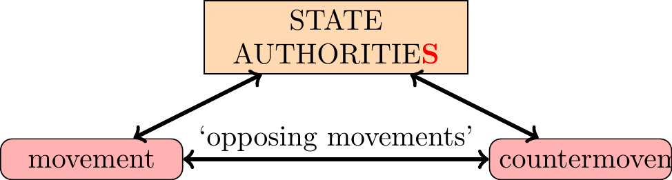

- but **the state** is usually the most important creater of opportunity structure
  - which state authoritie**s** are involved?
  - what are those authorities’ posture?
    - passive or active? (is the state mediating?)
    - neutral or partial

## Countermovements - inherently disadvantaged?

One thesis has it that: **countermovements are inherently disadvantaged**. This might be because…

- movements can create ideology $\rightarrow$ (reactive) countermovements: ‘not this!’
  - **justifying a negative** often harder rhetorically than **change/hope**
  - Problems of the ‘*broad church*’: many opponents, many possible reasons for opposition
  - challenging the originating movement’s **frames**
    - 1. What’s the problem? (b) Who’s to blame? (c) How should it change? (d) Why should we care?

## Countermovements - inherently disadvantaged?

One thesis has it that: **countermovements are inherently disadvantaged**. This might be because…

- movements can create ideology $\rightarrow$ (reactive) countermovements: ‘not this!’
  - **justifying a negative** often harder rhetorically than **change/hope**
  - Problems of the ‘*broad church*’: many opponents, many possible reasons for opposition
  - challenging the originating movement’s **frames**
    - 1. What’s the problem? (b) Who’s to blame? (c) How should it change? (d) Why should we care?
    - **refresher**: how are these **frames** labelled?

## next meeting

- social movements online
- in the meantime…

*Io Saturnalia!* and happy holidays

# Any questions, concerns, feedback for this class?

Anonymous feedback here: https://forms.gle/AjHt6fcnwZxkSg4X8

Alternatively, please send me an email: m.zeller@lmu.de

Questions about movements next meeting: (1) Is online activity very important to the movement? (2) What is the most important use of online tools for this movement? (3) Do most new supporters first encounter the movement online? (4) Does online participation frequently lead to offline participation? (5) Which online platform is most important for the movement? (6) Has the movement been affected by social media content moderation policies? (7) Does online participation gives supporters a meaningful sense of belonging, even without attending offline events?

## References

Conlon, Rob. 2017. “Leeds United, Racism, and the Fanzine Which Forced Change at Elland Road.” *Planet Football*, September.

Jetzt.de. 2019“,,Hate Fascism“: Unbekannte Antworten Auf Rechtes Symbol in Cottbus.” *Jetzt.de*, December.

Kienzl, Philipp. 2019. “Wie Es Aktivist*innen Gelang, Paypal-Zahlungen an Rechtsextreme Zu Stoppen.” *Ze.tt*, November, 1–3.

Lennard, Natasha. 2018. “Is Antifa Counterproductive? White Nationalist Richard Spencer Would Beg to Differ.” *The Intercept*, March.

Lo, Clarence H. 1982. “Countermovements and Conservative Movements in the Contemporary U.S.” *Annual Review of Sociology* 8: 107–34.

Mayer, Nonna. 1995. “The Dynamics of the Anti-Front National Countermovement.” *French Politics and Society* 13 (4): 12–32.

Meyer, David S, and Suzanne Staggenborg. 1996. “Movements, Countermovements, and the Structure of Political Opportunity.” *American Journal of Sociology* 101 (6): 1628–60.

———. 2008. “Opposing Movement Strategies in U.S. Abortion Politics.” In *Research in Social Movements, Conflicts and Change, Volume 28*, edited by Patrick G Coy, 209–38. Bingley: Emerald Group Publishing.

Mottl, Tahi L. 1980. “The Analysis of Countermovements.” *Social Problems* 27 (5): 620–35.

Nasr, Joseph. 2021. “Pranksters Target German Far-Right Party with Election Campaign Stunt.” *Reuters*, September.

Reynolds-Stenson, Heidi, and Jennifer Earl. 2018. “Clashes of Conscience:Explaining Counterdemonstration At Protests.” *Mobilization: An International Quarterly* 23 (3): 263–84. https://doi.org/10.17813/1086-671X-23-3-263.

von Jutrczenka, Bernd. 2018. “Künstlergruppe Schaltet Umstrittene Website Ab.” *Zeit Online*, December.

Weisskircher, Manès. 2023. “Austria: ’Protecting Democracy’ in the Context of an Established Far-Right Lager. Counterprotest Against a Far-Right Ball.” In *Civil Democracy Protection: Success Conditions of Non-Governmental Organizations in Comparison*, edited by Uwe Backes and Thomas Lindenberger. London: Routledge.

Zald, Mayer N, and Bert Useem. 1987. “Movement and Countermovement Interaction: Mobilization, Tactics, and State Involvement.” In *Social Movements in an Organizational Society*, 247–71. New Brunswick: Transaction Books.